Week 1 Assignment

A. 10 pts Task: Perform EDA on the dataset. Include both quantitative and qualitative descriptions. Check for missing data and correlations.

```python
import pandas as pd
import matplotlib.pyplot as plt
import seaborn as sns
#Loading the dataset
data= data = pd.read_csv("hw1_data.csv")
```

```python
print("First few rows of the dataset:")
print(data.head())
```

```
First few rows of the dataset:
         Date        IWM        QQQ         SPY
0  2000-05-26  34.800865  67.670738   93.363678
1  2000-05-30  36.085365  74.470436   96.408173
2  2000-05-31  36.216213  72.348938   96.619591
3  2000-06-01  37.036850  76.048004   98.310966
4  2000-06-02  38.963646  81.487755  100.023491
```

```python
#Checking for missing values
print("\nMissing data in each column:")
print(data.isnull().sum())
```

```
Missing data in each column:
Date    0
IWM     0
QQQ     0
SPY     0
dtype: int64
```

```python
#Summary statistics
print("\nSummary statistics:")
print(data.describe())
```

```
Summary statistics:
               IWM          QQQ          SPY
count  4972.000000  4972.000000  4972.000000
mean     77.254619    70.539066   134.360431
std      38.722995    49.057235    66.778492
min      25.456144    17.459492    53.503864
25%      46.092833    34.344567    85.923027
50%      63.785954    48.595505   105.741215
75%     106.390139    99.085045   180.474552
max     167.320114   235.638428   332.137360
```

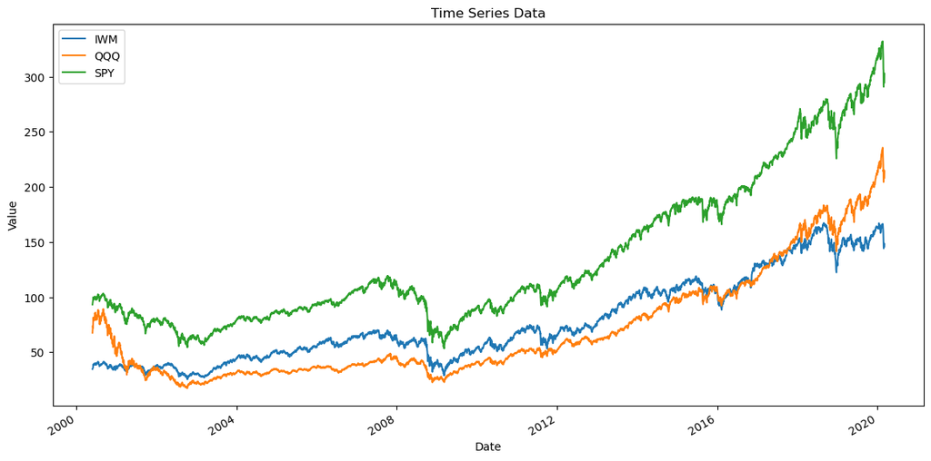

```python
# Converting the Date column to datetime
data['Date'] = pd.to_datetime(data['Date'])

# Plotting the time series
plt.figure(figsize=(14, 7))
plt.plot(data['Date'], data['IWM'], label='IWM')
plt.plot(data['Date'], data['QQQ'], label='QQQ')
plt.plot(data['Date'], data['SPY'], label='SPY')
plt.title('Time Series Data')
plt.xlabel('Date')
plt.ylabel('Value')
plt.legend()
plt.gcf().autofmt_xdate()

plt.show()
```

```
Correlation matrix:
          IWM       QQQ       SPY
IWM  1.000000  0.950877  0.982987
QQQ  0.950877  1.000000  0.986423
SPY  0.982987  0.986423  1.000000
```

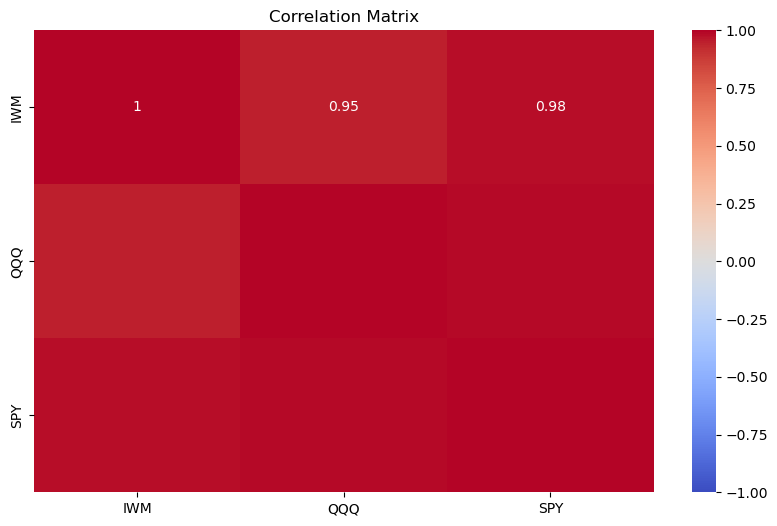

```python
import seaborn as sns
import matplotlib.pyplot as plt

# Calculating the correlation matrix
correlation_matrix = data[['IWM', 'QQQ', 'SPY']].corr()

# Printing the correlation matrix
print("Correlation matrix:")
print(correlation_matrix)

# Creating a heatmap to visualize the correlations
plt.figure(figsize=(10, 6))
sns.heatmap(correlation_matrix, annot=True, cmap='coolwarm', vmin=-1, vmax=1)
plt.title('Correlation Matrix')
plt.show()
```

B.5 pts Concept: Describe the data. Do you expect this data to be stationary? Do you expect this data to be a random walk?

No. I don't expect this data to be stationary. Data may exibit trends over the time due to seasnality, economic factors, inflation, etc. Market volatility might lead to heteroscedasticity.They likely contain trends and varying volatility over time.I expect this data to be a random walk. Price changes are random and unpredictable.

C.10 pts Task: Create a function that returns the stationarity test results from both ADF and KPSS tests

```python
import warnings
from statsmodels.tsa.stattools import kpss
# Suppress InterpolationWarning
warnings.filterwarnings("ignore", category=Warning)
```

```python
import warnings
import numpy as np
import pandas as pd
from statsmodels.tsa.stattools import adfuller, kpss
warnings.filterwarnings("ignore", category=pd.errors.PerformanceWarning)
warnings.filterwarnings("ignore", category=pd.errors.SettingWithCopyWarning)

def stationarity_tests(time_series):
    # ADF Test
    adf_result = adfuller(time_series)
    adf_output = {
        'Test Statistic': adf_result[0],
        'p-value': adf_result[1],
        'Lags Used': adf_result[2],
        'Number of Observations Used': adf_result[3],
        'Critical Values': adf_result[4],
        'ADF Test Result': 'Stationary' if adf_result[1] < 0.20 else 'Non-Stationary'
    }

    # KPSS Test
    kpss_result = kpss(time_series, regression='c', nlags="auto")
    kpss_output = {
        'Test Statistic': kpss_result[0],
        'p-value': kpss_result[1],
        'Lags Used': kpss_result[2],
        'Critical Values': kpss_result[3],
        'KPSS Test Result': 'Non-Stationary' if kpss_result[1] < 0.05 else 'Stationary'
    }

    return {
        'ADF Test': adf_output,
        'KPSS Test': kpss_output
    }
```

D.5 pts Task: Use the function to test if each series is stationary. Return results from both ADF and KPSS tests for all three time series.

```python
import numpy as np
import pandas as pd
from statsmodels.tsa.stattools import adfuller, kpss

# Function to perform stationarity tests
def stationarity_tests(time_series):
    # ADF Test
    adf_result = adfuller(time_series)
    adf_output = {
        'Test Statistic': adf_result[0],
        'p-value': adf_result[1],
        'Lags Used': adf_result[2],
        'Number of Observations Used': adf_result[3],
        'Critical Values': adf_result[4],
        'ADF Test Result': 'Stationary' if adf_result[1] < 0.05 else 'Non-Stationary'

    }

    # KPSS Test
    kpss_result = kpss(time_series, regression='c', nlags="auto")
    kpss_output = {
        'Test Statistic': kpss_result[0],
        'p-value': kpss_result[1],
        'Lags Used': kpss_result[2],
        'Critical Values': kpss_result[3],
        'KPSS Test Result': 'Non-Stationary' if kpss_result[1] < 0.05 else 'Stationary'
    }

    return {
        'ADF Test': adf_output,
        'KPSS Test': kpss_output
    }
# Testing the function on all three time series
results_iwm = stationarity_tests(data['IWM'])
results_qqq = stationarity_tests(data['QQQ'])
results_spy = stationarity_tests(data['SPY'])

results_iwm, results_qqq, results_spy
```

```python
# Testing the function on all three time series
results_iwm = stationarity_tests(data['IWM'])
results_qqq = stationarity_tests(data['QQQ'])
results_spy = stationarity_tests(data['SPY'])

# Printing results with specific formatting
print(" Test Result for IWM:")
print(results_iwm)
print("\n Test Result for QQQ:")
print(results_qqq)
print("\n Test Result for SPY:")
print(results_spy)
```

[output not shown]

E: Difference the three time series and return stationarity results from both ADF and KPSS tests

```python
IWM = data['IWM'].tolist()
QQQ = data['QQQ'].tolist()
SPY = data['SPY'].tolist()
```

```python
import pandas as pd
from statsmodels.tsa.stattools import adfuller, kpss

def difference_and_stationarity_tests(series):
    # Compute first differences
    diff_series = series.diff().dropna()  # Drop NA resulting from differencing

    # Performing ADF test
    adf_result = adfuller(diff_series)
    adf_statistic = adf_result[0]
    adf_p_value = adf_result[1]

    # Performing KPSS test
    kpss_result = kpss(diff_series, regression='c', nlags="auto")
    kpss_statistic = kpss_result[0]
    kpss_p_value = kpss_result[1]

    # Returning results
    return {
        'ADF Statistic': adf_statistic,
        'ADF p-value': adf_p_value,
        'KPSS Statistic': kpss_statistic,
        'KPSS p-value': kpss_p_value
    }

# Applying the function to each time series
results_iwm = difference_and_stationarity_tests(data['IWM'])
results_qqq = difference_and_stationarity_tests(data['QQQ'])
results_spy = difference_and_stationarity_tests(data['SPY'])

# Printing results
print("Results for IWM:")
print(results_iwm)
print("\nResults for QQQ:")
print(results_qqq)
print("\nResults for SPY:")
print(results_spy)
```

```
Results for IWM:
{'ADF Statistic': -7.979140684375767, 'ADF p-value': 2.652300978237717e-12, 'KPSS Statistic': 0.13293399872123882, 'KPSS p-value': 0.1}

Results for QQQ:
{'ADF Statistic': -6.425505537120757, 'ADF p-value': 1.7486484751740378e-08, 'KPSS Statistic': 0.299353490175749, 'KPSS p-value': 0.1}

Results for SPY:
{'ADF Statistic': -7.206054973023282, 'ADF p-value': 2.2987190425884802e-10, 'KPSS Statistic': 0.324930720354281, 'KPSS p-value': 0.1}
```

F. In general, explain how you can get different stationarity results from the two tests.

5 pts Concept: What does trend stationary mean?

Ans: Trend stationarity refers to a type of stationarity in time series data where the mean and variance are constant over time, except for a predictable trend component.

2.Random Walk – 50 pts A.5 pts Task: Using random.sample create a sample with length 1000 of 1 if >=0.5 and -1 if less than 0.5

```python
import random

# Generating a sample of length 1000 with values 1 and -1 based on random numbers
sample = [1 if random.random() >= 0.5 else -1 for _ in range(1000)]

# Printing the first few elements of the sample to verify
print(sample[:10])  # Printing first 10 elements as an example
```

```
[1, 1, 1, -1, -1, 1, 1, -1, -1, 1]
```

```python
B. 5 pts Task: Use cumulative sum to create movement
```

```python
import numpy as np

# Computing cumulative sum to create movement
movement = np.cumsum(sample)

print(movement[:10])  # Printing first 10 elements as an example
```

```
[1 2 3 2 1 2 3 2 1 2]
```

C.5 pts Concept: Describe which of the two series (2a or 2b) is a random walk, why? What is the other series?

D.5 pts Task: Create two plots of the random walk time series, use .plot() and use autocorrelation_plot()

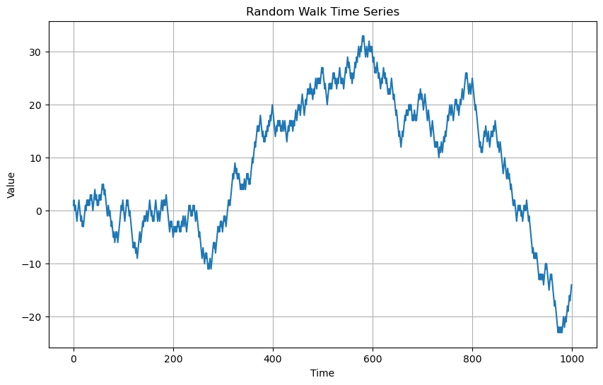

```python
import random
import numpy as np
import pandas as pd
import matplotlib.pyplot as plt
from pandas.plotting import autocorrelation_plot

# Generating a sample of length 1000 with values 1 and -1 based on random numbers
sample_random_walk = [1 if random.random() >= 0.5 else -1 for _ in range(1000)]

# Computing cumulative sum to create random walk
random_walk = np.cumsum(sample_random_walk)

# Converting to a pandas Series for easier plotting and analysis
random_walk_series = pd.Series(random_walk)

# Plotting the random walk time series
plt.figure(figsize=(10, 6))
random_walk_series.plot()
plt.title('Random Walk Time Series')
plt.xlabel('Time')
plt.ylabel('Value')
plt.grid(True)
plt.show()
```

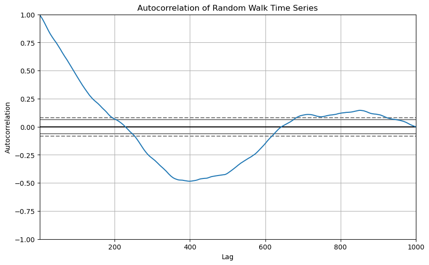

```python
# Plotting the autocorrelation of the random walk time series
plt.figure(figsize=(10, 6))
autocorrelation_plot(random_walk_series)
plt.title('Autocorrelation of Random Walk Time Series')
plt.xlabel('Lag')
plt.ylabel('Autocorrelation')
plt.grid(True)
plt.show()
```

10 pts Concept: Is the random walk stationary? Defend using quantitative tests.

Ans: We can use ADF and KPSS test to determine whether a random walk is stationary. Both the ADF and KPSS tests provide evidence that the random walk series is non-stationary:

The ADF test suggests the presence of a unit root (non-stationarity) due to the non-rejection of Null hypothesis. The KPSS test confirms non-trend-stationarity due to the rejection of Null hypothesis.

Therefore, based on these quantitative tests, we conclude that the random walk is not stationary.They exhibit trends and movements that are not stationary over time.

```python
import numpy as np
import pandas as pd
from statsmodels.tsa.stattools import adfuller, kpss

# Generating a random walk time series
np.random.seed(123)
random_walk = np.cumsum(np.random.normal(0, 1, 1000))  # Example of a random walk with normal shocks

# Performing ADF test
adf_result = adfuller(random_walk)
print(f'ADF Statistic: {adf_result[0]}')
print(f'ADF p-value: {adf_result[1]}')

# Performing KPSS test
kpss_result = kpss(random_walk)
print(f'KPSS Statistic: {kpss_result[0]}')
print(f'KPSS p-value: {kpss_result[1]}')
```

```
ADF Statistic: -0.3841821411553095
ADF p-value: 0.9127064826326521
KPSS Statistic: 2.330608620744924
KPSS p-value: 0.01
```

5 pts Task: Difference the data and show the autocorrelation plot

```python
# Differencing the data
differenced_iwm = data['IWM'].diff().dropna()
differenced_qqq = data['QQQ'].diff().dropna()
differenced_spy = data['SPY'].diff().dropna()
```

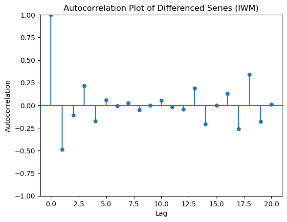

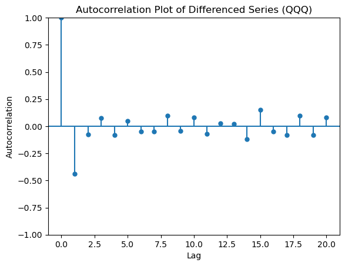

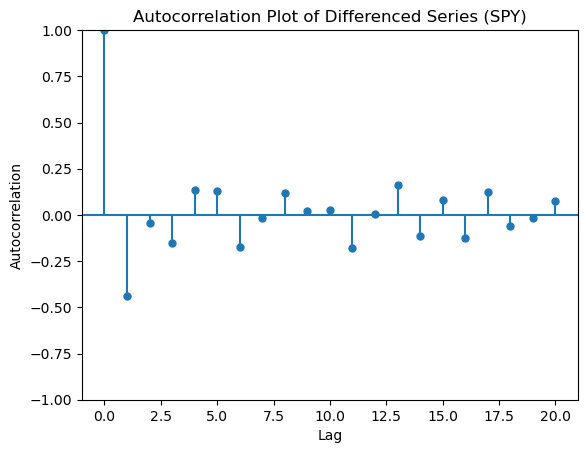

```python
# Plotting autocorrelation for IWM with lines and dots
plt.figure(figsize=(10, 6))
plot_acf(differenced_iwm, lags=20, title='Autocorrelation Plot of Differenced Series (IWM)', alpha=None, use_vlines=True, unbiased=False, fft=False, missing='none')
plt.xlabel('Lag')
plt.ylabel('Autocorrelation')
plt.show()

# Plotting autocorrelation for QQQ with lines and dots
plt.figure(figsize=(10, 6))
plot_acf(differenced_qqq, lags=20, title='Autocorrelation Plot of Differenced Series (QQQ)', alpha=None, use_vlines=True, unbiased=False, fft=False, missing='none')
plt.xlabel('Lag')
plt.ylabel('Autocorrelation')
plt.show()

# Plotting autocorrelation for SPY with lines and dots
plt.figure(figsize=(10, 6))
plot_acf(differenced_spy, lags=20, title='Autocorrelation Plot of Differenced Series (SPY)', alpha=None, use_vlines=True, unbiased=False, fft=False, missing='none')
plt.xlabel('Lag')
plt.ylabel('Autocorrelation')
plt.show()
```

G. 10 pts Concept: What is the significance of this correlation plot?

Ans : In our context of financial time series data, autocorrelation plots can reveal whether past stock prices influence future prices, indicating trends. Further helps in understanding how past returns or prices relate to future returns. Autocorrelation plots provide insights into market dynamics, trends, trading strategies, risk management, and model selection. They help in understanding the temporal dependencies within the data, guiding decisions and strategies in financial analysis and investment management. Understanding these autocorrelation patterns is crucial for making informed decisions in financial markets.

H. Can a random walk be predicted? Why or why not?

Ans: A random walk cannot be predicted in a reliable manner due to its inherent randomness, independence of increments, and the efficiency of markets in reflecting all available information.Random walk has characteristics such as no trend or pattern, Independent Increments, effecient market hypothesis. Given these characteristics , a random walk cannot be predicted with reasons such as lack of patterns, market effeciency, randomness and uncertainity.

THE END!!